# HW 02 - Data Wrangling

Hanke Zheng

### Download and Read in the data

First download and then read in with data.table:fread()

```r
# download individual/regional data from github
download.file("https://raw.githubusercontent.com/USCbiostats/data-science-data/master/01_chs/chs_individual.csv", "chs_individual.csv", method="libcurl", timeout = 60)
individual <- data.table::fread("chs_individual.csv")

download.file("https://raw.githubusercontent.com/USCbiostats/data-science-data/master/01_chs/chs_regional.csv", "chs_regional.csv", method="libcurl", timeout = 60)
regional <- data.table::fread("chs_regional.csv")

library(data.table)
library(dtplyr)
library(dplyr)
```

There are 1200 raws and 23 coloumns in the individual dataset; 12 raws and 27 variables in the regional dataset. ### Merge

```r
## merge the two dataset by location
ind_region <- merge(x = individual, y = regional, by.x = "townname", by.y = "townname", all.x = TRUE, all.y = FALSE)

count_n <- merge(x = individual, y = regional, by.x = "townname", by.y = "townname", all.x = TRUE, all.y = FALSE) %>%nrow()
```

The # of the merged dataset is the same as that of the individual dataset - no duplicates.

### Manipulate the data

```r
# check the missing values for bmi
message("Missing: ", ind_region[is.na(bmi), .N])
```

```
## Missing: 89
```

```r
# impute data using the average within the variables “male” and “hispanic"
ind_region[, bmi_imp := fcoalesce(bmi, mean(bmi, na.rm = TRUE)),
    by = .(male, hispanic)]
ind_region$bmi[is.na(ind_region$bmi)] <- ind_region$bmi_imp
# check the missing values for fev
message("Missing: ", ind_region[is.na(fev), .N])
```

```
## Missing: 95
```

```r
# impute data using the average within the variables “male” and “hispanic"
ind_region[, fev_imp := fcoalesce(fev, mean(fev, na.rm = TRUE)),
    by = .(male, hispanic)]
ind_region$fev[is.na(ind_region$fev)] <- ind_region$fev_imp
# Create a new categorical variable named “obesity_level” using the BMI measurement (underweight BMI<14; normal BMI 14-22; overweight BMI 22-24; obese BMI>24).
ind_region$obesity_level <- ifelse(ind_region$bmi>= 14 & ind_region$bmi<= 22, "normal",
                         ifelse(ind_region$bmi<14, "underweight",
                                ifelse(ind_region$bmi > 24, "obese", "overweight")))
table(ind_region$obesity_level)
```

```
##
##      normal       obese  overweight underweight
##         959         109          95          37
```

```r
range(ind_region$bmi)
```

```
## [1] 11.29640 41.26613
```

```r
# check the missing values for binary variables 'smoke' and 'gasstove'
message("Missing: ", ind_region[is.na(smoke), .N])
```

```
## Missing: 40
```

```r
message("Missing: ", ind_region[is.na(gasstove), .N])
```

```
## Missing: 33
```

```r
# Create another categorical variable named “smoke_gas_exposure” that summarizes “Second Hand Smoke” and “Gas Stove.” The variable should have four categories in total.
ind_region$smoke_gas_exposure <- ifelse(ind_region$smoke== 1 & ind_region$gasstove == 1, "exposed to both",
                         ifelse(ind_region$smoke==1 & ind_region$gasstove != 1, "exposed to smoke",
                        ifelse(ind_region$smoke !=1 & ind_region$gasstove == 1, "exposed to gas stove", "not exposed to both")))
table(ind_region$smoke_gas_exposure)
```

```
##
##      exposed to both exposed to gas stove     exposed to smoke
##                  151                  739                   36
##  not exposed to both
##                  214
```

# Summary Table

```r
#Create four summary tables showing the average (or proportion, if binary) and sd of “Forced expiratory volume in 1 second (ml)” and asthma indicator by town, sex, obesity level, and “smoke_gas_exposure.”
# convert to data frame
ind_region_df <- as.data.frame(ind_region)
# by town
ind_region_df %>%
  group_by(townname) %>%
  summarise(fev_ave = mean(fev),
            fev_sd = sd(fev),
            prop_asthma = mean(asthma, na.rm = TRUE),
            asthma_sd = sd(asthma, na.rm = TRUE)
  )
```

```
## # A tibble: 12 x 5
##    townname      fev_ave fev_sd prop_asthma asthma_sd
##    <chr>           <dbl>  <dbl>       <dbl>     <dbl>
##  1 Alpine          2096.   299.       0.113     0.319
##  2 Atascadero      2083.   327.       0.255     0.438
##  3 Lake Elsinore   2039.   311.       0.126     0.334
##  4 Lake Gregory    2090.   322.       0.152     0.360
##  5 Lancaster       2012.   342.       0.165     0.373
##  6 Lompoc          2035.   355.       0.113     0.319
##  7 Long Beach      1982.   322.       0.135     0.344
##  8 Mira Loma       2004.   350.       0.158     0.367
##  9 Riverside       1993.   281.       0.11      0.314
## 10 San Dimas       2025.   320.       0.172     0.379
## 11 Santa Maria     2026.   328.       0.134     0.342
## 12 Upland          2034.   363.       0.121     0.328
```

```r
# by sex
ind_region_df %>%
  group_by(male) %>%
  summarise(fev_ave = mean(fev),
            fev_sd = sd(fev),
            prop_asthma = mean(asthma, na.rm = TRUE),
            asthma_sd = sd(asthma, na.rm = TRUE)
  )
```

```
## # A tibble: 2 x 5
##    male fev_ave fev_sd prop_asthma asthma_sd
##   <int>   <dbl>  <dbl>       <dbl>     <dbl>
## 1     0   1971.   329.       0.121     0.326
## 2     1   2101.   313.       0.173     0.378
```

```r
# by obesity level
ind_region_df %>%
  group_by(obesity_level) %>%
  summarise(fev_ave = mean(fev),
            fev_sd = sd(fev),
            prop_asthma = mean(asthma, na.rm = TRUE),
            asthma_sd = sd(asthma, na.rm = TRUE)
  )
```

```
## # A tibble: 4 x 5
##   obesity_level fev_ave fev_sd prop_asthma asthma_sd
##   <chr>           <dbl>  <dbl>       <dbl>     <dbl>
## 1 normal          2004.   310.      0.141      0.349
## 2 obese           2249.   328.      0.198      0.400
## 3 overweight      2221.   308.      0.163      0.371
## 4 underweight     1715.   307.      0.0811     0.277
```

```r
# by smoke_gas_exposure
ind_region_df %>%
  group_by(smoke_gas_exposure) %>%
  summarise(fev_ave = mean(fev),
            fev_sd = sd(fev),
            prop_asthma = mean(asthma, na.rm = TRUE),
            asthma_sd = sd(asthma, na.rm = TRUE)
  )
```

```
## # A tibble: 5 x 5
##   smoke_gas_exposure   fev_ave fev_sd prop_asthma asthma_sd
##   <chr>                  <dbl>  <dbl>       <dbl>     <dbl>
## 1 exposed to both        2023.   308.       0.130     0.338
## 2 exposed to gas stove   2032.   327.       0.148     0.355
## 3 exposed to smoke       2046.   371.       0.171     0.382
## 4 not exposed to both    2056.   335.       0.148     0.356
## 5 <NA>                   2018.   346.       0.149     0.360
```

### 4. Exploratory Data Analysis

- 1. What is the association between BMI and FEV (forced expiratory volume)?
- 2. What is the association between smoke and gas exposure and FEV?
- 3. What is the association between PM2.5 exposure and FEV?

# Facet plot showing scatterplots with regression lines of BMI vs FEV by “townname”.

```r
library(leaflet)
library(tidyverse)
```

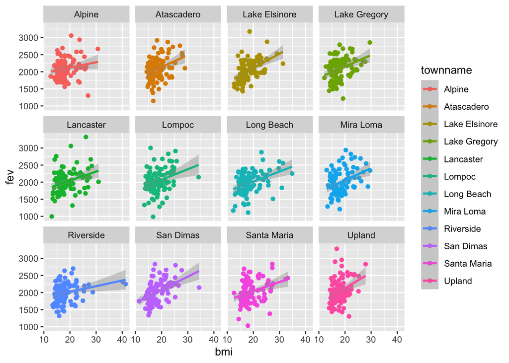

```r
library(ggplot2)

ind_region_df %>%
  filter(!(townname %in% NA)) %>%
  ggplot(mapping=aes(x=bmi, y=fev, color=townname)) +
  geom_point()+
  stat_smooth(method=lm)+
  facet_wrap(~townname)
```

A positive association was observed between BMI and FEV based on the scatterplots.

#Stacked histograms of FEV by BMI category and FEV by smoke/gas exposure. Use different color schemes than the ggplot default.

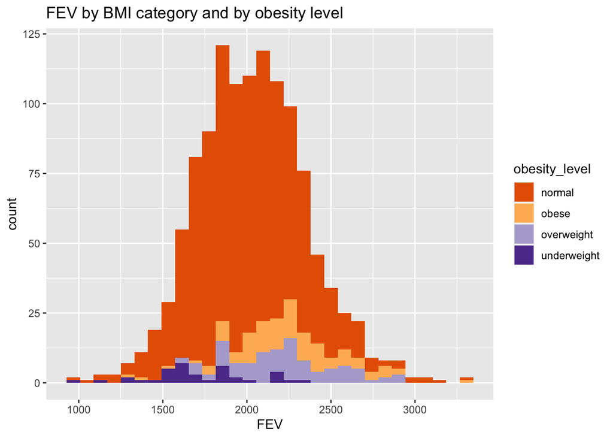

```r
ind_region_df %>%
  ggplot()+
  geom_histogram(mapping=aes(x=fev,fill=obesity_level))+
  # change the default palette
  scale_fill_brewer(palette = "PuOr")+
  labs(title="FEV by BMI category and by obesity level", x="FEV", y="count")
```

```r
  theme()
```

```
##  Named list()
##  - attr(*, "class")= chr [1:2] "theme" "gg"
##  - attr(*, "complete")= logi FALSE
##  - attr(*, "validate")= logi TRUE
```

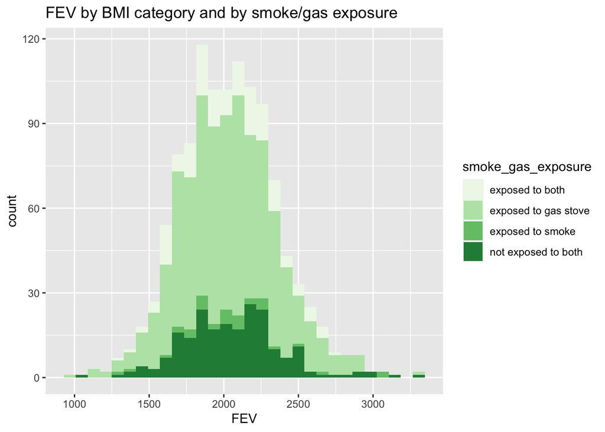

```r
ind_region_df %>%
  filter(!(smoke_gas_exposure %in% NA)) %>%
  ggplot()+
  geom_histogram(mapping=aes(x=fev,fill=smoke_gas_exposure))+
  # change the default palette
  scale_fill_brewer(palette = "Zissou")+
  labs(title="FEV by BMI category and by smoke/gas exposure", x="FEV", y="count")
```

```r
  theme()
```

```
##  Named list()
##  - attr(*, "class")= chr [1:2] "theme" "gg"
##  - attr(*, "complete")= logi FALSE
##  - attr(*, "validate")= logi TRUE
```

FEV is normally distributed by obesity level and exposure status.

# Barchart of BMI by smoke/gas exposure.

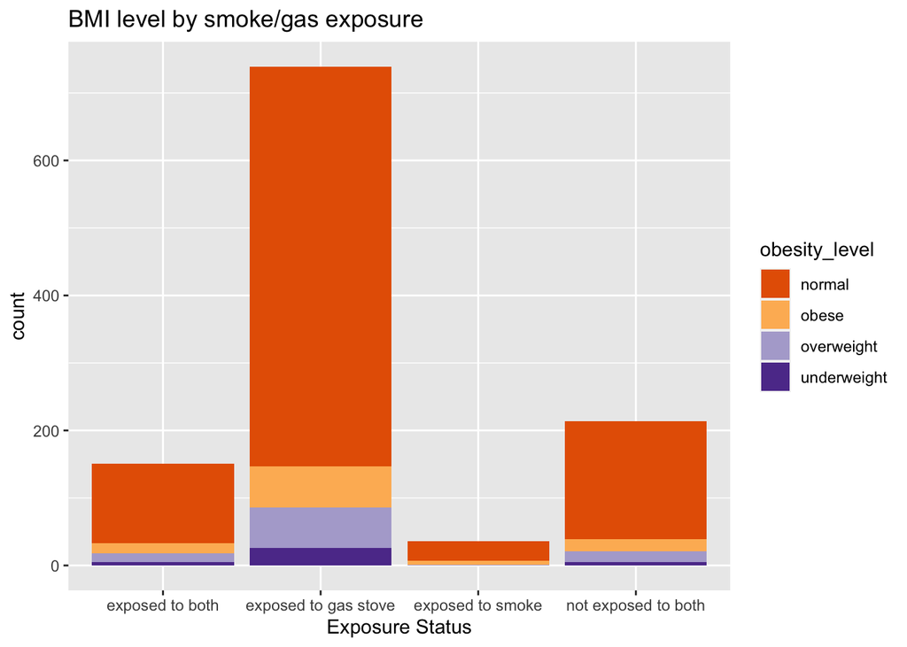

```r
ind_region_df %>%
  filter(!(smoke_gas_exposure %in% NA)) %>%
  ggplot()+
  geom_bar(mapping=aes(x=smoke_gas_exposure,fill=obesity_level))+
  # change the default palette
  scale_fill_brewer(palette = "PuOr")+
  labs(title="BMI level by smoke/gas exposure", x="Exposure Status", y="count")
```

```r
  theme()
```

```
##  Named list()
##  - attr(*, "class")= chr [1:2] "theme" "gg"
##  - attr(*, "complete")= logi FALSE
##  - attr(*, "validate")= logi TRUE
```

The majority of people in different exposure status are within normal BMI level.

#Statistical summary graphs of FEV by BMI and FEV by smoke/gas exposure category.

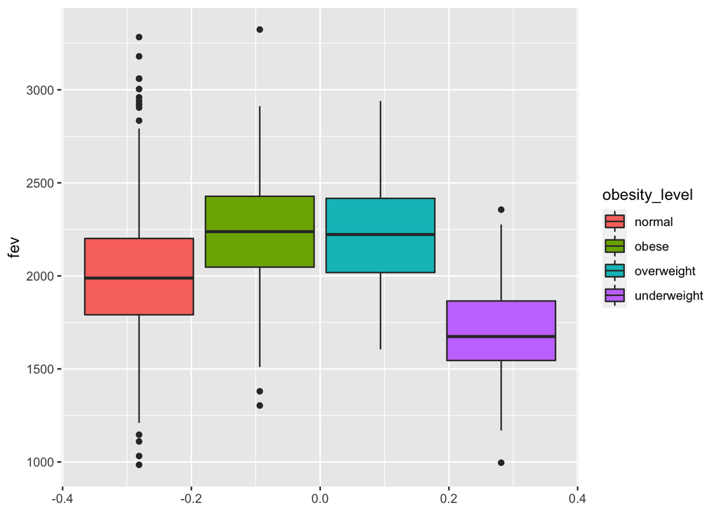

```r
ind_region_df %>%
ggplot() +
  geom_boxplot(mapping=aes(y=fev, fill=obesity_level))
```

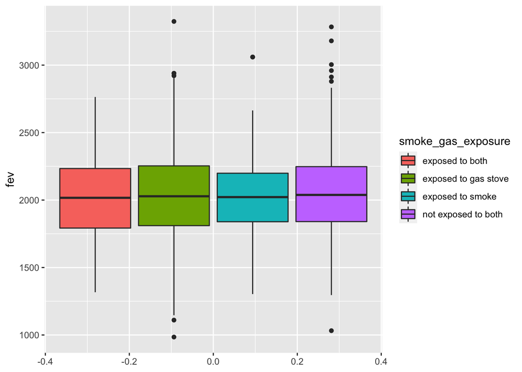

```r
ind_region_df %>%
    filter(!(smoke_gas_exposure %in% NA)) %>%
    ggplot() +
    geom_boxplot(mapping=aes(y=fev, fill=smoke_gas_exposure))
```

#A leaflet map showing the concentrations of PM2.5 mass in each of the CHS communities.

```r
library(leaflet)
leaflet(ind_region_df) %>%
  addProviderTiles('OpenStreetMap') %>%
  addCircles(lat=~lat, lng=~lon, color="green",opacity=1,
             fillOpacity=1, radius=~(pm25_mass*300))
```

[interactive chart not shown]

The PM2.5 level is relatively high in LA areas in comparative to areas in the northern California.

# Choose a visualization to examine whether PM2.5 mass is associated with FEV.

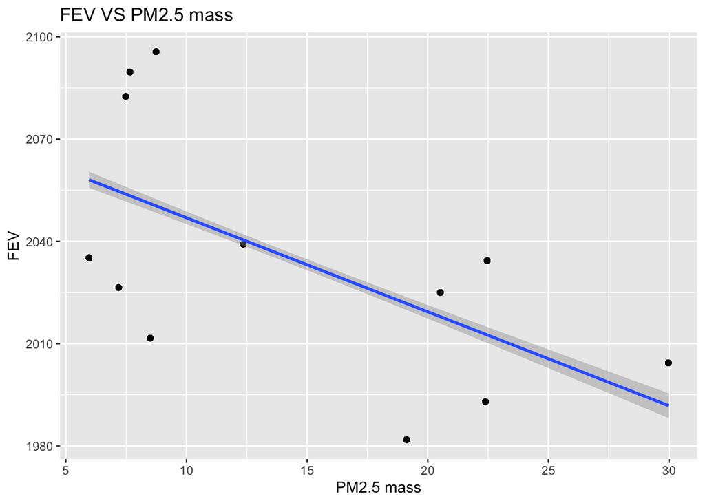

```r
ind_region[,fev_ave :=mean(fev),by=townname]
ind_region %>%
  ggplot(mapping = aes(x=pm25_mass, y=fev_ave))+
  geom_point()+
  stat_smooth(method=lm)+
  labs(titles="FEV VS PM2.5 mass", x="PM2.5 mass", y="FEV")
```

Using the average FEV for each town, a negatvie association between PM2.5 and FEV was observed.